# Introduction to R and RStudio

### 2.1.1 Look at the variables inside a data.frame

To specify a single variable from a data.frame, use the dollar sign `$`.

Let’s explore a numeric variable: life expectancy.

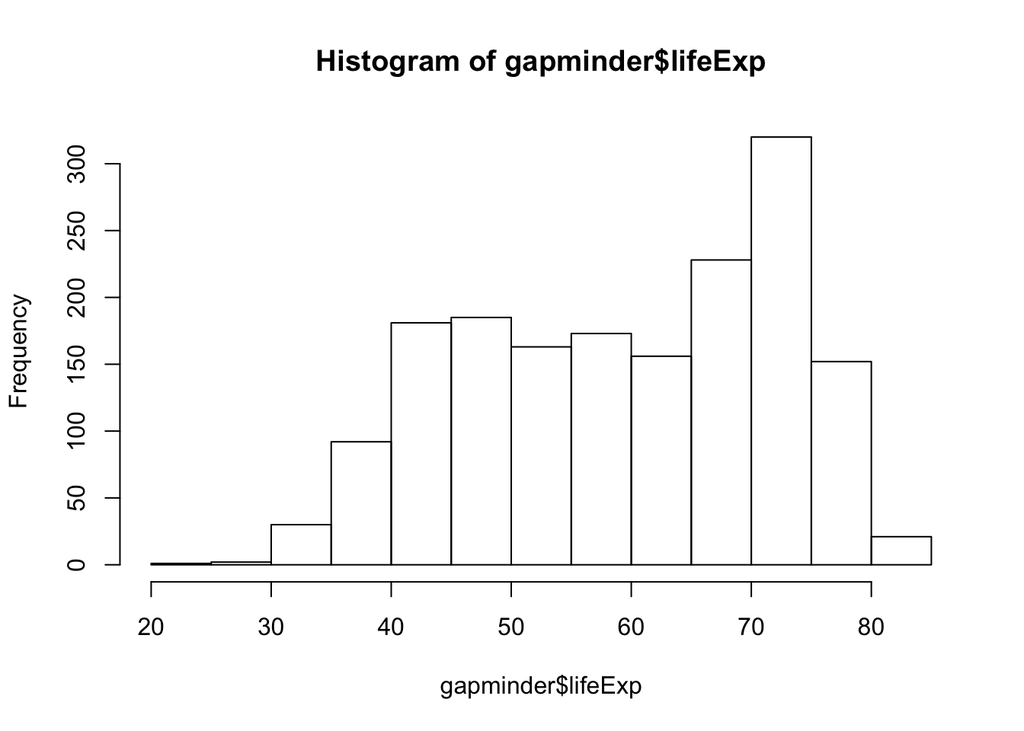

```r
## explore numeric variable
summary(gapminder$lifeExp)
##    Min. 1st Qu.  Median    Mean 3rd Qu.    Max.
##   23.60   48.20   60.71   59.47   70.85   82.60
hist(gapminder$lifeExp)
```

Let’s explore a categorical variable (stored as a *factor* in R): continent.

```r
## explore factor variable
summary(gapminder$continent)
##   Africa Americas     Asia   Europe  Oceania
##      624      300      396      360       24
levels(gapminder$continent)
## [1] "Africa"   "Americas" "Asia"     "Europe"   "Oceania"
nlevels(gapminder$continent)
## [1] 5
hist(gapminder$continent) # whaaaa!?
## Error in hist.default(gapminder$continent): 'x' must be numeric
```

This error is because of what factors are ‘under the hood’: R is really storing integer codes 1, 2, 3 here, but represent them as text to us. Factors can be problematic to us because of this, but you can learn to navigate with them. There are resources to learn how to [properly care and feed for factors](http://stat545.com/block014_factors.html).

One thing you’ll learn is how to visualize factors with which functions/packages.

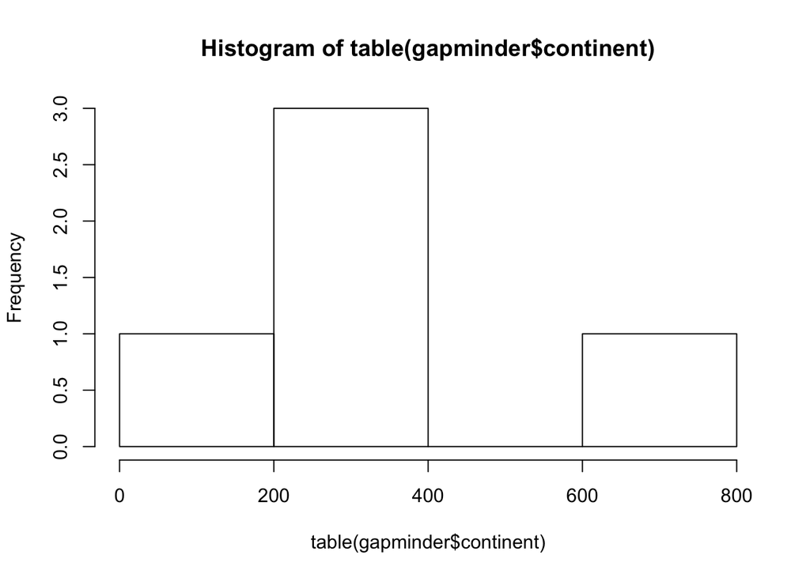

```r
class(gapminder$continent) # ?class returns the class type of the object
## [1] "factor"
table(gapminder$continent) # ?table builds a table based on factor levels
##
##   Africa Americas     Asia   Europe  Oceania
##      624      300      396      360       24
class(table(gapminder$continent)) # this has morphed the factor...
## [1] "table"
hist(table(gapminder$continent)) # so we can plot!
```

I don’t want us to get too bogged down with what’s going on with `table()` and plotting factors, but I want to expose you to these situations because you will encounter them. Googling the error messages you get, and knowing how to look for good responses is a critical skill. (I tend to look for responses from stackoverflow.com that are recent and have green checks, and ignore snarky comments).

> Exercise with your neighbor: Explore `gapminder$gdpPercap`. What kind of data is it? So which commands do you use?

## 2.2 Isolating bits of data.frames

You will want to isolate bits of your data.frames; maybe you want to just look at Africa or years since 2000. R calls this subsetting.

There is a stand-alone function called `subset()`, that can isolate pieces of an object for inspection or assignment. `subset()`’s main argument is also (unfortunately) called `subset`. Remember your logical expressions from this morning? We’ll use `==` here.

```r
## subset gapminder
subset(gapminder, subset = country == "Uruguay") # Ah, inspecting Uruguay. Self documenting!
##      country year     pop continent lifeExp gdpPercap
## 1621 Uruguay 1952 2252965  Americas  66.071  5716.767
## 1622 Uruguay 1957 2424959  Americas  67.044  6150.773
## 1623 Uruguay 1962 2598466  Americas  68.253  5603.358
## 1624 Uruguay 1967 2748579  Americas  68.468  5444.620
## 1625 Uruguay 1972 2829526  Americas  68.673  5703.409
## 1626 Uruguay 1977 2873520  Americas  69.481  6504.340
## 1627 Uruguay 1982 2953997  Americas  70.805  6920.223
## 1628 Uruguay 1987 3045153  Americas  71.918  7452.399
## 1629 Uruguay 1992 3149262  Americas  72.752  8137.005
## 1630 Uruguay 1997 3262838  Americas  74.223  9230.241
## 1631 Uruguay 2002 3363085  Americas  75.307  7727.002
## 1632 Uruguay 2007 3447496  Americas  76.384 10611.463
```

Contrast the above command with this one accomplishing the same thing:

```r
gapminder[1621:1632, ] # No idea what we are inspecting. Don't do this.
##      country year     pop continent lifeExp gdpPercap
## 1621 Uruguay 1952 2252965  Americas  66.071  5716.767
## 1622 Uruguay 1957 2424959  Americas  67.044  6150.773
## 1623 Uruguay 1962 2598466  Americas  68.253  5603.358
## 1624 Uruguay 1967 2748579  Americas  68.468  5444.620
## 1625 Uruguay 1972 2829526  Americas  68.673  5703.409
## 1626 Uruguay 1977 2873520  Americas  69.481  6504.340
## 1627 Uruguay 1982 2953997  Americas  70.805  6920.223
## 1628 Uruguay 1987 3045153  Americas  71.918  7452.399
## 1629 Uruguay 1992 3149262  Americas  72.752  8137.005
## 1630 Uruguay 1997 3262838  Americas  74.223  9230.241
## 1631 Uruguay 2002 3363085  Americas  75.307  7727.002
## 1632 Uruguay 2007 3447496  Americas  76.384 10611.463
```

Yes, these both return the same result. But the second command is horrible for these reasons:

- It contains Magic Numbers. The reason for keeping rows 1621 to 1632 will be non-obvious to someone else and that includes **you** in a couple of weeks.
- It is fragile. If the rows of `gapminder` are reordered or if some observations are eliminated, these rows may no longer correspond to the Uruguay data.

In contrast, the first command, using `subset()`, is **self-documenting**; one does not need to be an R expert to take a pretty good guess at what’s happening. It’s also more robust. It will still produce the correct result even if `gapminder` has undergone some reasonable set of transformations (what if it were in in reverse alphabetical order?)

You can use `subset =` and `select =` together to simultaneously filter rows and columns or variables.

```r
subset(gapminder, subset = country == "Mexico",
       select = c(country, year, lifeExp)) # ?c: combines values into a vector or list
##     country year lifeExp
## 985  Mexico 1952  50.789
## 986  Mexico 1957  55.190
## 987  Mexico 1962  58.299
## 988  Mexico 1967  60.110
## 989  Mexico 1972  62.361
## 990  Mexico 1977  65.032
## 991  Mexico 1982  67.405
## 992  Mexico 1987  69.498
## 993  Mexico 1992  71.455
## 994  Mexico 1997  73.670
## 995  Mexico 2002  74.902
## 996  Mexico 2007  76.195
```

You can also subset more than one condition using `&`, `|`, etc. Let’s take a peek at logical operators: `?"&"`

```r
subset(gapminder, subset = country == c("Mexico", "Uruguay") & year == 2007)
##      country year     pop continent lifeExp gdpPercap
## 1632 Uruguay 2007 3447496  Americas  76.384  10611.46
```

> Exercise: with a partner,  
> 1. subset data of interest using at least 2 conditionals.  
> 2. assign this to a variable.  
> 3. what did you learn?

```r
# one potential exercise answer, no peeking
gap_sample = subset(gapminder, subset = country == c("France", "Brazil") & year >= 2002)
head(gap_sample)
str(gap_sample)
```

## 2.3 conditional statements with `if` and `else`

Often when we’re coding we want to control the flow of our actions. This can be done by setting actions to occur only if a condition or a set of conditions are met. Alternatively, we can also set an action to occur a particular number of times.

```r
# if
if (condition is true) {
  do something
}

# if ... else
if (condition is true) {
  do something
} else {  # that is, if the condition is false,
  do something different
}
```

Say, for example, that we want R to print a message if the variable we just created has a has a particular value.

```r
# sample a random number from a Poisson distribution
# with a mean (lambda) of 8

x <- rpois(1, lambda=8)

if (x >= 10) {
  print("x is greater than or equal to 10")
}

x
## [1] 9
```

Note you may not get the same output as your neighbour because you may be sampling different random numbers from the same distribution.

Let’s go a step further:

```r
x <- rpois(1, lambda=8)

if (x >= 10) {
  print("x is greater than or equal to 10")
} else if (x > 5) {
  print("x is greater than 5")
} else {
  print("x is less than 5")
}
## [1] "x is less than 5"
```

**Important:** when R evaluates the condition inside `if` statements, it is looking for a logical element, i.e., `TRUE` or `FALSE`. This can cause some headaches. For example:

```r
x  <-  4 == 3
if (x) {
  "4 equals 3"
}
```

As we can see, the message was not printed because the vector x is `FALSE`

```r
x <- 4 == 3
x
## [1] FALSE
```

> Exercise: Use an `if` statement to print a suitable message reporting whether there are any records from 2002 in the `gapminder` dataset. Now do the same for 2012.

Did anyone get a warning message like this?

```r
if (gapminder$year == 2002) {
  print('this will only check the first element in gapminder$year')
  }
## Warning in if (gapminder$year == 2002) {: the condition has length > 1 and
## only the first element will be used
```

If your condition evaluates to a vector with more than one logical element, the function `if` will still run, but will only evaluate the condition in the first element. Remember our analogy about spoken language? This is when R understood your command, but flagging that you may have misspoken. R isn’t saying ‘what!?’ (that’s an error message), it’s saying ‘I understood what you said, but I want to alert you that it might not be what you meant’. These warning messages can be really helpful, but you can’t rely that they will catch all misinterpretations.

We’ll talk about a good way to do this tomororw, but in case you wanted to just do a quick check to see if 2002 was even in the gapminder data, you could use `any` or `%in%`

```r
if (any(gapminder$year == 2002)) {
  print('yes 2002 is included at least once in gapminder')
}
## [1] "yes 2002 is included at least once in gapminder"

if (2002 %in% gapminder$year) {
  print('yes 2002 is included at least once in gapminder')
  }
## [1] "yes 2002 is included at least once in gapminder"
```

## 2.4 Repeating operations with for loops

If you want to iterate over a set of values, and perform the same operation on each, a `for` loop will do the job. We saw `for` loops in the shell lessons earlier.

The basic structure of a `for` loop is:

```r
for(iterator in set of values){
  do a thing
}
```

For example:

```r
for(i in 1:10){
  print(i)
}
```

The `1:10` bit creates a vector on the fly; you can iterate over any other vector as well.

We can use a `for` loop nested within another `for` loop to iterate over two things at once.

```r
for (i in 1:5){
  for(j in c('a', 'b', 'c', 'd', 'e')){
    print(paste(i,j))
  }
}
```

```r
for (gap_cont in unique(gapminder$continent)){ # gap_cont = 'Africa'
  temp <-  subset(gapminder, continent == gap_cont)
  print(paste('mean life expectency for', gap_cont, 'is', mean(temp$lifeExp)))
}
## [1] "mean life expectency for Asia is 60.0649032323232"
## [1] "mean life expectency for Europe is 71.9036861111111"
## [1] "mean life expectency for Africa is 48.8653301282051"
## [1] "mean life expectency for Americas is 64.6587366666667"
## [1] "mean life expectency for Oceania is 74.3262083333333"
```

Rather than printing the results, we could write the loop output to a new object.

```r
continent_mean_lifeExp <- c()
for (gap_cont in unique(gapminder$continent)){  # gap_cont = 'Africa'
  temp                   <-  subset(gapminder, continent == gap_cont)
  temp_output            <-  paste(gap_cont, mean(temp$lifeExp))
  continent_mean_lifeExp <- c(continent_mean_lifeExp, temp_output)
}
continent_mean_lifeExp
## [1] "Asia 60.0649032323232"     "Europe 71.9036861111111"
## [3] "Africa 48.8653301282051"   "Americas 64.6587366666667"
## [5] "Oceania 74.3262083333333"
```

This approach can be useful, but ‘growing your results’ (building the result object incrementally) is computationally inefficient, so avoid it when you are iterating through a lot of values.

For loops can also lead to temporary variables that you don’t need. Tomorrow we will learn about a few packages that will help your data wrangling well beyond for loops!

## 2.5 clean up and save your .r script

OK, let’s clean up and save your `.r` script, we’ll be using it again tomorrow! Restart R. This will ensure you don’t have any packages loaded from previous calls to `library()`. In RStudio, use *Session > Restart R*. Otherwise, quit R with `q()` and re-launch it.

Run through each line of code again, make sure your comments are good, delete anything you don’t need. Your script might look like this:

```r
## explore the gapminder dataset ----
gapminder = read.csv('data/gapminder-FiveYearData.csv')
str(gapminder) #displays the structure of an object
head(gapminder) # shows first 6 by default
tail(gapminder, 12)# shows last X that you indicate, or 6 by default
names(gapminder)
dim(gapminder)    # ?dim dimension
ncol(gapminder)   # ?ncol number of columns
nrow(gapminder)   # ?nrow number of rows
length(gapminder) # ?length length; although better for vectors
summary(gapminder)

## plot gapminder
plot(lifeExp ~ year, gapminder)
plot(lifeExp ~ gdpPercap, gapminder)

## explore numeric variable
head(gapminder$lifeExp)
summary(gapminder$lifeExp)
hist(gapminder$lifeExp)

## explore numeric variable that functions like a categorical variable
head(gapminder$year)
summary(gapminder$year)

## explore factor variable
class(gapminder$continent)
summary(gapminder$continent)
levels(gapminder$continent)
nlevels(gapminder$continent)
barplot(table(gapminder$continent))

## subset gapminder. Self documenting!
subset(gapminder, subset = country == "Mexico",
       select = c(country, year, lifeExp)) # ?c: combines values

## practice an if statement
x <- rpois(1, lambda=8)

if (x >= 10) {
  print("x is greater than or equal to 10")
} else if (x > 5) {
  print("x is greater than 5")
} else {
  print("x is less than 5")
}

## two ways to see if values exist: `any` and `%in%`
if (any(gapminder$year == 2002)) {
  print('yes 2002 is included at least once in gapminder')
}
if (2002 %in% gapminder$year) {
  print('yes 2002 is included at least once in gapminder')
}

## practice a for loop
continent_mean_lifeExp <- c()
for (gap_cont in unique(gapminder$continent)){  # gap_cont = 'Africa'
  temp                   <-  subset(gapminder, continent == gap_cont)
  temp_output            <-  paste(gap_cont, mean(temp$lifeExp))
  continent_mean_lifeExp <- c(continent_mean_lifeExp, temp_output)
}
continent_mean_lifeExp
```